# Is the four-class leadership solution robust to setting and occupation? A multiple-group LCA of general vs hospital workers

Multiple-group latent class analysis (glca) of the Constructive-Destructive Leadership Scale, comparing the general salaried-worker survey (FONDECYT 1170239) with the hospital healthcare-worker sample, using 13 of the 14 items (item 3 excluded). Tests whether the retained four-class solution is invariant across the two settings (measurement invariance), whether the profile *distribution* differs, and whether a different number of classes / new profiles emerge in either group. Explores 1-6 classes.

Author

Andres Gonzalez Santa Cruz

Published

July 2, 2026

# What this notebook does

The main analysis retains **four** latent leadership profiles in the general salaried-worker survey. Here we ask whether that structure is **robust to place and occupation** by bringing in a second sample — hospital healthcare workers, measured with the *same* Constructive-Destructive Leadership Scale — and fitting a **multiple-group LCA** with `glca`.

Three distinct questions, three distinct outputs:

| Question | How it is answered here | Section |
| --- | --- | --- |
| Does the pooled two-group data still support ~4 classes? | Multiple-group enumeration, `nclass` = 1-6 (`measure.inv = TRUE`) | *Enumeration (pooled)* |
| Are the profiles **the same** across settings (measurement invariance)? | Compare `measure.inv = TRUE` (item probs shared) vs `FALSE` (item probs free) at k = 3-5, LRT via `gofglca` + information criteria | *Measurement invariance* |
| Does the **mix** of profiles differ between settings? | Group-specific class prevalences from the invariant 4-class model | *Group-specific prevalences* |
| Do **new** classes appear in either group? | Separate single-group enumeration (each sample alone, k = 2-6) + side-by-side 4-class profiles | *Separate enumeration* / *Profile comparison* |

**Interpretation key.** If measurement invariance *holds* (relaxing it does not improve fit and the invariant model has the lower BIC), the same four item-response profiles exist in both settings and the four-class solution is robust to setting/occupation; the two samples may still differ in *how many workers* fall in each profile (prevalences). If invariance is *rejected*, the item-response probabilities defining one or more profiles differ by setting, and the separate-enumeration / profile-comparison sections show how.

> **`[[ COMPLETAR ]]` — set by hand (one place, next chunk):** (i) the two file paths (relative to your Google-Drive root), and (ii) the item column names in the hospital file. The general file uses `lid_des1..14`; the hospital file is assumed to use `p39_1..14` (crosswalk `p39_k <-> lid_des_k`). If the hospital columns are named differently, edit `hosp_items` — the loader prints what it found and stops with guidance if the names do not match.

```r
rm(list = ls()); gc()

required_packages <- c(
  "dplyr", "tidyr", "tibble", "purrr", "haven", "readr", "janitor", "stringr", "rlang",
  "glca",
  "ggplot2", "scales",
  "knitr", "kableExtra"
)
invisible(lapply(required_packages, function(pkg) {
  if (!requireNamespace(pkg, quietly = TRUE))
    install.packages(pkg, repos = "https://cloud.r-project.org")
  suppressPackageStartupMessages(library(pkg, character.only = TRUE))
}))
set.seed(2125)                 # same lucky seed as the main analysis
options(scipen = 999)

## Random starts per glca() fit. Multiple-group fits are HEAVIER than the
## single-group ones in the main file (two groups x measure.inv TRUE/FALSE x
## several k x separate single-group fits), so this defaults LOWER than the 4000
## used for the reportable single-group models in leadership_LCA_analysis.qmd and
## leadership_LCA_8class_sensitivity.qmd. DRAFT = 200 (fast pipeline check);
## FINAL/REPORTABLE = 4000, triggered EITHER by options(lca.final = TRUE) OR by the
## environment variable LCA_FINAL=1 (handy for a one-off: `LCA_FINAL=1 quarto render`
## with no file edit). An ordinary quarto render sets neither and stays at 200.
n_init <- if (isTRUE(getOption("lca.final", FALSE)) || Sys.getenv("LCA_FINAL") == "1") 4000L else 200L
```

```
          used (Mb) gc trigger (Mb) max used (Mb)
Ncells  598579 32.0    1367004 73.1   686442 36.7
Vcells 1107402  8.5    8388608 64.0  1877019 14.4
```

# Data: load both samples and harmonise the 13 items

```r
## ---- path resolver (same idea as the main analysis) ---------------------
## Tries H:, G:, C: and uses the first root where the file exists, so the qmd
## does not break if Google Drive changes drive letter or is opened on another PC.
## Keep only the RELATIVE path (relative to the Google-Drive root).
resolve_drive_path <- function(rel,
    roots = c("H:/My Drive", "G:/Mi unidad", "C:/Users/andre/Google Drive")) {
  rel <- gsub("\\\\", "/", rel)
  for (r in roots) { p <- file.path(r, rel); if (file.exists(p)) return(p) }
  stop("No se encontro el archivo en ninguna raiz conocida:\n  ",
       paste(file.path(roots, rel), collapse = "\n  "),
       "\nAgrega la raiz correcta a 'roots'.")
}
read_any <- function(path) {
  switch(tolower(tools::file_ext(path)),
    dta = haven::read_dta(path), sav = haven::read_sav(path),
    rds = readRDS(path), csv = readr::read_csv(path, show_col_types = FALSE),
    stop("Extension no soportada: ", tools::file_ext(path)))
}

## ======================= [[ COMPLETAR ]] — CONFIG ========================
## (i) file paths, RELATIVE to the Google-Drive root (the resolver adds H:/G:/C:)
gen_rel  <- "DOCUMENTOS/6.TESIS 2018/LCA NAQ/BD_2020_input3_match_not_miss.rds"
hosp_rel <- "DOCUMENTOS/6.TESIS 2018/_BASE DEF_FINAL/andrea/Base de datos 27.8.2019.dta"

## (ii) item columns in EACH file, in the SAME conceptual order, item 3 excluded.
##      Crosswalk is positional: gen_items[j] and hosp_items[j] must be the SAME
##      leadership behavior. General uses lid_des1..14; hospital is assumed p39_1..14.
gen_items  <- paste0("lid_des", c(1:2, 4:14))   # 13 items, lid_des3 dropped
hosp_items <- paste0("p39_",    c(1:2, 4:14))   # 13 items, p39_3 dropped
## ========================================================================

## Common (harmonised) item names used for the pooled model.
common_items <- sprintf("I%02d", seq_along(gen_items))   # I01..I13

gen_path  <- resolve_drive_path(gen_rel)
hosp_path <- resolve_drive_path(hosp_rel)
message("General file : ", gen_path)
```

```
General file : H:/My Drive/DOCUMENTOS/6.TESIS 2018/LCA NAQ/BD_2020_input3_match_not_miss.rds
```

```r
message("Hospital file: ", hosp_path)
```

```
Hospital file: H:/My Drive/DOCUMENTOS/6.TESIS 2018/_BASE DEF_FINAL/andrea/Base de datos 27.8.2019.dta
```

```r
gen_raw  <- read_any(gen_path)  |> janitor::clean_names()
hosp_raw <- read_any(hosp_path) |> janitor::clean_names()

## ---- defensive check that the item columns exist ------------------------
check_items <- function(df, items, label) {
  miss <- setdiff(items, names(df))
  if (length(miss)) {
    cand <- grep("^(lid_des|p39_)[0-9]+$", names(df), value = TRUE)
    stop("En la base '", label, "' faltan estas columnas de items: ",
         paste(miss, collapse = ", "),
         "\nColumnas tipo item detectadas: ",
         if (length(cand)) paste(cand, collapse = ", ") else "(ninguna)",
         "\nEdita 'gen_items'/'hosp_items' para que coincidan.")
  }
  invisible(TRUE)
}
check_items(gen_raw,  gen_items,  "general")
check_items(hosp_raw, hosp_items, "hospital")

## ---- harmonise: select 13 items, shift 0-3 -> 1-4 per file, factor 1:4 ---
## Each file is shifted INDEPENDENTLY based on its own minimum: the general .rds
## is coded 0-3 (shifted +1 in the main analysis) and the hospital .dta is
## expected 0-3 as well, but this is decided per file so a 1-4 file is left alone.
prep_group <- function(df, items, common, group_label) {
  x <- df[, items, drop = FALSE]
  names(x) <- common
  item_min <- suppressWarnings(min(vapply(x,
                function(v) min(as.numeric(v), na.rm = TRUE), numeric(1))))
  shift <- if (is.finite(item_min) && item_min == 0) 1L else 0L
  for (nm in common) x[[nm]] <- factor(as.numeric(x[[nm]]) + shift, levels = 1:4)
  if (shift == 1L) message("[", group_label, "] items recodificados 0-3 -> 1-4 (+1).")
  x$setting <- group_label
  x
}
gen_h  <- prep_group(gen_raw,  gen_items,  common_items, "General salaried")
hosp_h <- prep_group(hosp_raw, hosp_items, common_items, "Hospital HCW")
```

```
[Hospital HCW] items recodificados 0-3 -> 1-4 (+1).
```

```r
## Pool, keep complete cases on the 13 items, make setting an (ordered) factor.
combo <- dplyr::bind_rows(gen_h, hosp_h)
combo <- combo[stats::complete.cases(combo[, common_items]), ]
combo$setting <- factor(combo$setting, levels = c("General salaried", "Hospital HCW"))

cat("Complete-case n by setting:\n"); print(table(combo$setting))
cat("\nPooled n =", nrow(combo), "on", length(common_items), "items.\n")
```

```
Complete-case n by setting:

General salaried     Hospital HCW
            1847              972

Pooled n = 2819 on 13 items.
```

```r
## Manuscript handoff: the text currently states only the POOLED complete-case n;
## the per-setting n (general vs hospital) must be quotable too. Export both plus
## a ready-to-paste sentence (house style: no space before '=', e.g. 'n= 1,991').
n_by <- table(combo$setting)
sizes_tbl <- tibble::tibble(
  Setting = c(names(n_by), "Pooled"),
  n       = c(as.integer(n_by), nrow(combo)),
  n_init  = n_init)
readr::write_csv(sizes_tbl, "mg_sample_sizes.csv")
cat(sprintf(
  "Manuscript-ready: complete cases on the 13 items were n= %s general salaried workers and n= %s hospital workers (pooled n= %s).\n",
  format(as.integer(n_by)[1], big.mark = ","),
  format(as.integer(n_by)[2], big.mark = ","),
  format(nrow(combo), big.mark = ",")))
```

```
Manuscript-ready: complete cases on the 13 items were n= 1,847 general salaried workers and n= 972 hospital workers (pooled n= 2,819).
```

```r
## Sanity check on the crosswalk/coding: mean endorsement of the top-2 categories
## (fairly often + almost always) per item, per setting. Constructive items
## should be HIGH in both settings and destructive items LOW; a flipped or
## mismatched item would show up as a reversed pattern here. Eyeball before trusting.
endorse <- combo |>
  tidyr::pivot_longer(dplyr::all_of(common_items), names_to = "item", values_to = "v") |>
  dplyr::mutate(top2 = as.integer(as.numeric(v) >= 3)) |>
  dplyr::group_by(setting, item) |>
  dplyr::summarise(pct_top2 = round(100 * mean(top2, na.rm = TRUE), 1), .groups = "drop") |>
  tidyr::pivot_wider(names_from = setting, values_from = pct_top2)

## map I01.. back to the source item names for readability
endorse$gen_col  <- gen_items[match(endorse$item, common_items)]
endorse$hosp_col <- hosp_items[match(endorse$item, common_items)]
endorse |>
  dplyr::select(item, gen_col, hosp_col, dplyr::everything()) |>
  knitr::kable("markdown", caption = "Harmonisation check: % endorsing the top-2 categories per item, by setting (constructive items should be high in BOTH; destructive/laissez-faire low). Verify the crosswalk before interpreting the models.")
```

Harmonisation check: % endorsing the top-2 categories per item, by setting (constructive items should be high in BOTH; destructive/laissez-faire low). Verify the crosswalk before interpreting the models.

| item | gen_col | hosp_col | General salaried | Hospital HCW |
| --- | --- | --- | --- | --- |
| I01 | lid_des1 | p39_1 | 3.7 | 3.5 |
| I02 | lid_des2 | p39_2 | 37.1 | 34.2 |
| I03 | lid_des4 | p39_4 | 10.1 | 11.6 |
| I04 | lid_des5 | p39_5 | 10.3 | 12.9 |
| I05 | lid_des6 | p39_6 | 51.3 | 48.7 |
| I06 | lid_des7 | p39_7 | 16.0 | 16.7 |
| I07 | lid_des8 | p39_8 | 5.1 | 4.4 |
| I08 | lid_des9 | p39_9 | 10.4 | 7.5 |
| I09 | lid_des10 | p39_10 | 4.0 | 1.7 |
| I10 | lid_des11 | p39_11 | 45.9 | 47.3 |
| I11 | lid_des12 | p39_12 | 48.5 | 50.5 |
| I12 | lid_des13 | p39_13 | 60.7 | 63.8 |
| I13 | lid_des14 | p39_14 | 55.5 | 58.5 |

# Helpers (entropy, per-group posteriors, rho, information criteria)

```r
## Relative entropy (0-1; higher = cleaner separation) from a posterior matrix.
relative_entropy <- function(post) {
  post <- as.matrix(post)
  N <- nrow(post); K <- ncol(post)
  if (K < 2) return(NA_real_)
  e <- -sum(post * log(pmax(post, 1e-12)))
  1 - e / (N * log(K))
}

## glca stores multiple-group posteriors as a LIST (one matrix per group). This
## returns that list regardless of single/multi group so pooled entropy and
## per-group prevalences work uniformly.
get_post_list <- function(g) {
  p <- g$posterior
  if (is.matrix(p) || is.data.frame(p)) list(as.matrix(p))
  else lapply(p, as.matrix)
}
pooled_entropy <- function(g) relative_entropy(do.call(rbind, get_post_list(g)))

## Per-group class prevalences = mean posterior within each group (robust; does
## not depend on glca's internal gamma/prior slot names). Rows aligned to the
## group factor levels in the order glca returns them.
group_prev <- function(g, group_levels) {
  pl <- get_post_list(g)
  m  <- t(vapply(pl, function(p) colMeans(p), numeric(ncol(pl[[1]]))))
  nm <- names(pl)
  rownames(m) <-
    if (!is.null(nm) && all(nzchar(nm)) && length(nm) == nrow(m)) nm
    else if (length(group_levels) == nrow(m)) group_levels
    else paste0("G", seq_len(nrow(m)))
  colnames(m) <- paste0("C", seq_len(ncol(m)))
  m
}

## Item-response probabilities. For a SINGLE-group fit, rho[[item]] is K x 4.
## For a multi-group measure.inv = FALSE fit, rho is nested by group; pick a group.
get_rho <- function(g, group = 1L) {
  r <- g$param$rho
  if (is.list(r) && is.list(r[[1]])) r <- r[[group]]   # unwrap group level if present
  r
}
## Top-2 endorsement (categories 3+4) per item x class, from a rho list.
top2_mat <- function(rho, K) {
  m <- t(vapply(seq_along(rho), function(j) rho[[j]][, 3] + rho[[j]][, 4], numeric(K)))
  rownames(m) <- common_items; colnames(m) <- paste0("C", 1:K)
  m
}

## Defensive scalar getters (slot names vary slightly by glca version).
gof_get <- function(g, what) {
  gg <- g$gof
  cand <- switch(what, loglik = c("loglik","logLik","ll"),
                       aic = c("aic","AIC"), bic = c("bic","BIC"))
  for (nm in cand) if (!is.null(gg[[nm]])) return(as.numeric(gg[[nm]])[1])
  NA_real_
}
## npar recovered from AIC and logL: AIC = -2 logL + 2 npar  ->  npar = (AIC + 2 logL)/2
npar_of <- function(g) { aic <- gof_get(g, "aic"); ll <- gof_get(g, "loglik"); (aic + 2 * ll) / 2 }

## Fit a multiple-group glca with a seed fallback (belt-and-suspenders against a
## rare degenerate random start, exactly as in the main enumeration chunk).
## glca evaluates `group` by non-standard evaluation inside `data`, so the group
## must be a BARE column name (as in glca's own examples: group = DEGREE), not a
## vector. The pooled data frame always names the grouping column `setting`.
fit_mg <- function(nclass, measure.inv, data = combo, form = item_f) {
  RNGkind("Mersenne-Twister")
  g <- NULL
  for (s in 2125:2134) {
    g <- tryCatch(
      glca::glca(form, group = setting, data = data, nclass = nclass,
                 measure.inv = measure.inv, n.init = n_init, seed = s, verbose = FALSE),
      error = function(e) NULL)
    if (!is.null(g)) break
  }
  g
}
```

```r
## Behaviour type + English label for each of the 13 items (order = common_items,
## i.e. gen_items = lid_des1..14 with item 3 excluded). Defined ONCE here so BOTH
## the invariant-profiles chunk (labels the shared classes) and the profile-
## comparison chunk (separate-group figure) reuse the same metadata.
item_type <- c("Destructive","Constructive","Destructive","Laissez-faire",
               "Constructive","Laissez-faire","Destructive","Laissez-faire",
               "Destructive","Constructive","Constructive","Constructive","Constructive")
item_lab  <- c("Humiliates employees","Encourages creative ideas","Gestures of displeasure",
               "Avoids making decisions","Recognizes good performance","Avoids involvement in work",
               "Spreads false information","Absent when needed","Berates by phone / rude email",
               "Seeks to develop capabilities","Sets clear objectives","Defines / explains tasks",
               "Flexible, open to innovation")
stopifnot(length(item_type) == length(common_items), length(item_lab) == length(common_items))
```

# Enumeration (pooled two-group data), 1-6 classes

Multiple-group models with item-response probabilities **shared across settings** (`measure.inv = TRUE`) and setting-specific class prevalences. This asks how many profiles the pooled data supports.

```r
item_f <- as.formula(paste0("item(", paste(common_items, collapse = ", "), ") ~ 1"))
Kseq <- 1:6

n_pool <- nrow(combo)
enum_pooled <- purrr::map_dfr(Kseq, function(k) {
  g <- tryCatch(fit_mg(k, measure.inv = TRUE), error = function(e) NULL)
  if (is.null(g)) return(tibble::tibble(
    k = k, logLik = NA, npar = NA, AIC = NA, BIC = NA, CAIC = NA, SABIC = NA,
    AWE = NA, entropy = NA, `Mean AvePP` = NA, `Smallest n` = NA, `Smallest %` = NA))
  ll <- gof_get(g, "loglik"); aic <- gof_get(g, "aic"); bic <- gof_get(g, "bic")
  np <- (aic + 2 * ll) / 2

  ## AWE (Masyn 2013 form): -2logL + 2*npar*(3/2 + log n), pooled n
  awe <- -2 * ll + 2 * np * (1.5 + log(n_pool))

  ## pool the per-group posteriors, then modal assignment / smallest class / AvePP.
  ## k = 1 is safe here: post is N x 1, modal is all 1s, avepp = mean(1) = 1,
  ## smallest n = n_pool, smallest % = 100, entropy = NA (relative_entropy, K < 2).
  post  <- do.call(rbind, get_post_list(g))
  modal <- max.col(post)
  cl_n  <- as.integer(table(factor(modal, levels = 1:k)))
  avepp <- vapply(1:k, function(t)
             if (any(modal == t)) mean(post[modal == t, t]) else NA_real_, numeric(1))

  tibble::tibble(
    k = k, logLik = round(ll, 2), npar = round(np),
    AIC = round(aic, 2), BIC = round(bic, 2),
    CAIC  = round(-2 * ll + np * (log(n_pool) + 1), 2),
    SABIC = round(-2 * ll + np * log((n_pool + 2) / 24), 2),
    AWE   = awe,
    entropy = round(pooled_entropy(g), 3),
    `Mean AvePP` = mean(avepp, na.rm = TRUE),
    `Smallest n` = min(cl_n),
    `Smallest %` = min(cl_n) / n_pool * 100)
})

## approximate Bayes factor vs the k+1 neighbour: BF_{k,k+1} = exp((BIC_{k+1} - BIC_k)/2)
bic_next       <- enum_pooled$BIC[match(enum_pooled$k + 1L, enum_pooled$k)]
enum_pooled$BF <- exp((bic_next - enum_pooled$BIC) / 2)

## mark the IC minima (over the k that were estimable)
mark_min <- function(x) { i <- which(x == min(x, na.rm = TRUE)); out <- rep("", length(x)); out[i] <- "*"; out }
enum_show <- enum_pooled |>
  dplyr::mutate(
    BIC_min      = mark_min(BIC),
    CAIC_min     = mark_min(CAIC),
    AWE          = round(AWE, 2),
    `Mean AvePP` = round(`Mean AvePP`, 3),
    `Smallest %` = round(`Smallest %`, 1),
    BF = dplyr::case_when(
           is.na(BF) ~ NA_character_,
           BF > 100  ~ ">100",
           BF < 0.01 ~ "<0.01",
           TRUE      ~ sprintf("%.2f", BF))) |>
  dplyr::select(k, logLik, npar, AIC, BIC, BIC_min, CAIC, CAIC_min, SABIC, AWE,
                entropy, `Mean AvePP`, `Smallest n`, `Smallest %`, BF)
enum_show |>
  knitr::kable("markdown",
    caption = "Pooled multiple-group enumeration (measure.inv = TRUE): information criteria, relative entropy (pooled across both settings' posteriors; a single value can mask setting-specific separation), classification diagnostics (Mean AvePP, smallest-class n and %) and an approximate Bayes factor by number of classes. '*' marks the BIC and CAIC minima. nclass = 1 is the independence baseline (may not be estimable in glca).")
```

Pooled multiple-group enumeration (measure.inv = TRUE): information criteria, relative entropy (pooled across both settings’ posteriors; a single value can mask setting-specific separation), classification diagnostics (Mean AvePP, smallest-class n and %) and an approximate Bayes factor by number of classes. ’*’ marks the BIC and CAIC minima. nclass = 1 is the independence baseline (may not be estimable in glca).

| k | logLik | npar | AIC | BIC | BIC_min | CAIC | CAIC_min | SABIC | AWE | entropy | Mean AvePP | Smallest n | Smallest % | BF |
| --- | --- | --- | --- | --- | --- | --- | --- | --- | --- | --- | --- | --- | --- | --- |
| 1 | NA | NA | NA | NA |  | NA |  | NA | NA | NA | NA | NA | NA | NA |
| 2 | -36032.58 | 80 | 72225.15 | 72700.69 |  | 72780.69 |  | 72446.50 | 73576.22 | 0.863 | 0.960 | 1402 | 49.7 | <0.01 |
| 3 | -34206.32 | 121 | 68654.65 | 69373.89 |  | 69494.89 |  | 68989.43 | 70698.13 | 0.892 | 0.953 | 369 | 13.1 | <0.01 |
| 4 | -33049.64 | 162 | 66423.27 | 67386.22 |  | 67548.22 |  | 66871.49 | 69159.17 | 0.878 | 0.934 | 369 | 13.1 | <0.01 |
| 5 | -32505.50 | 203 | 65416.99 | 66623.65 |  | 66826.65 |  | 65978.65 | 68845.31 | 0.876 | 0.922 | 242 | 8.6 | <0.01 |
| 6 | -32217.69 | 244 | 64923.37 | 66373.74 | * | 66617.74 | * | 65598.47 | 69044.11 | 0.880 | 0.915 | 129 | 4.6 | NA |

*Notes.* **AWE** (Approximate Weight of Evidence; Masyn, 2013) = `-2*logL + 2*npar*(3/2 + log(n))`, evaluated on the pooled sample (`n = n_pool`) from the maximised model log-likelihood; it imposes a heavier, sample-size-adjusted complexity penalty than BIC, and lower values indicate better penalised fit (this uses the model log-likelihood, an approximation to the classification-based AWE). **BF** is a BIC-based approximate pairwise Bayes factor, `BF_{k,k+1} = exp((BIC_{k+1} - BIC_k)/2)`, comparing the k-class model with the (k+1)-class model: `BF > 3` is positive/moderate and `BF > 10` strong evidence for k over k+1 (values below `1/3` or `1/10` favour k+1); it is undefined for the largest k (no k+1 neighbour, shown blank) and is displayed capped at “>100”/“<0.01”. **Mean AvePP** is the average posterior class probability: for each class, the mean posterior probability of the modal class among cases modally assigned to it, averaged over classes; values near 1 indicate clean classification (about 0.70 is a common adequacy threshold). **Smallest n / Smallest %** give the count and percentage of the pooled sample in the smallest modally-assigned class; very small classes flag possible over-extraction or unstable solutions. **VLMR is omitted:** glca does not implement the Vuong-Lo-Mendell-Rubin (adjusted LMR) likelihood-ratio test, and it is not reliably defined for multiple-group LCA; class enumeration here rests on the information criteria (BIC, CAIC, AWE) and the BIC-based approximate Bayes factor rather than a VLMR/BLRT p-value.

# Measurement invariance: are the profiles the same across settings?

For each candidate `k`, fit the model with item-response probabilities **shared** (`measure.inv = TRUE`, nested) vs **free across settings** (`measure.inv = FALSE`). The likelihood-ratio test (via `gofglca`, cross-checked by hand) asks whether freeing the item probabilities improves fit; the information criteria ask whether that extra complexity is worth it. **The lead criterion here is BIC and the approximate Bayes factor** (the Cheng & Rensvold analog developed in the next subsection), because they are robust to the large-*n* over-rejection of the chi-square test: **invariance is supported when BIC(invariant) < BIC(free)** (equivalently ΔBIC = BIC(free) − BIC(invariant) ≥ 2 positive, ≥ 6 strong, ≥ 10 very strong evidence for invariance). The χ² LRT is reported alongside as a caveat only — with ~2,800 pooled complete cases it is over-powered and rejects almost automatically, so a significant LRT paired with a decisively lower invariant BIC reflects large-*n* over-rejection, not substantive non-invariance. (The lighter-penalty AIC and SABIC likewise lean toward the free model, and at k = 3 even BIC prefers the free model — see the tables below; these are reported for honesty, not as the deciding rule.)

> **Why chi-square (and not a bootstrap LRT) here.** The invariance null constrains item-response probabilities to be *equal* across settings at a fixed number of classes — an equality restriction in the interior of the parameter space — so the deviance difference is asymptotically chi-square(df) and the standard LRT applies. This is unlike the *number-of-classes* LRT (k vs k-1), whose null lies on the boundary of the parameter space and therefore requires a parametric bootstrap (BLRT). Because freeing the item probabilities adds many parameters over sparse 4-category tables (near-boundary rho estimates are possible), we do not lead with the LRT: as set out above and in the next subsection, the decision leads with BIC and the approximate Bayes factor, and the χ² LRT is reported only as a large-*n* caveat. Running `gofglca(..., test = "boot")` would give a finite-sample robustness check, but it is not needed to license the chi-square test.

```r
k_grid <- c(3, 4, 5)   # focus on the retained k = 4, with neighbours for context

inv_tbl <- purrr::map_dfr(k_grid, function(k) {
  g_inv  <- tryCatch(fit_mg(k, measure.inv = TRUE),  error = function(e) NULL)
  g_free <- tryCatch(fit_mg(k, measure.inv = FALSE), error = function(e) NULL)
  if (is.null(g_inv) || is.null(g_free))
    return(tibble::tibble(k = k, model = c("invariant","free"), logLik = NA,
                          npar = NA, AIC = NA, BIC = NA, LRT_stat = NA, LRT_df = NA, LRT_p = NA))
  ll_i <- gof_get(g_inv, "loglik");  ll_f <- gof_get(g_free, "loglik")
  np_i <- npar_of(g_inv);            np_f <- npar_of(g_free)
  ## manual LRT (robust): invariant (measure.inv = TRUE) is nested in free (FALSE),
  ## so stat = 2*(ll_f - ll_i) must be >= 0 and df = np_f - np_i > 0 at the maxima.
  stat <- 2 * (ll_f - ll_i)
  df   <- round(np_f - np_i)
  if (isTRUE(stat < 0)) {
    warning(sprintf(
      "k=%d: free-model logLik (%.2f) < invariant (%.2f). The less-constrained model failed to reach the global max (local optimum); raise n_init before trusting this LRT.",
      k, ll_f, ll_i))
    stat <- NA_real_
  }
  p <- if (isTRUE(stat >= 0) && isTRUE(df > 0)) stats::pchisq(stat, df = df, lower.tail = FALSE) else NA_real_
  ## canonical gofglca output (printed separately for the record)
  cat("\n---- gofglca(invariant, free) at k =", k, "----\n")
  print(tryCatch(glca::gofglca(g_inv, g_free, test = "chisq"),
                 error = function(e) paste("gofglca no disponible:", conditionMessage(e))))
  tibble::tibble(
    k = k,
    model  = c("invariant", "free"),
    logLik = round(c(ll_i, ll_f), 2),
    npar   = round(c(np_i, np_f)),
    AIC    = round(c(gof_get(g_inv, "aic"),  gof_get(g_free, "aic")), 2),
    BIC    = round(c(gof_get(g_inv, "bic"),  gof_get(g_free, "bic")), 2),
    LRT_stat = c(NA, round(stat, 2)),
    LRT_df   = c(NA, df),
    LRT_p    = c(NA, signif(p, 3)))
})
inv_tbl |>
  knitr::kable("markdown",
    caption = "Measurement-invariance test at k = 3-5. LRT compares the invariant model (item probs shared) against the free model (item probs differ by setting); the LRT row is shown on the 'free' line. The lead criterion is BIC (with the approximate Bayes factor in the next table): invariance is supported when BIC(invariant) < BIC(free); LRT_p is reported only as a large-n caveat, because at this pooled sample size the chi-square test over-rejects.")
```

```
---- gofglca(invariant, free) at k = 3 ----
Model 1: item(I01, I02, I03, I04, I05, I06, I07, I08, I09, I10, I11, I12,
    I13) ~ 1
         Group: setting, nclass: 3, measure.inv: TRUE
Model 2: item(I01, I02, I03, I04, I05, I06, I07, I08, I09, I10, I11, I12,
    I13) ~ 1
         Group: setting, nclass: 3, measure.inv: FALSE

Goodness of Fit Table :
     loglik      AIC      BIC entropy   df      Gsq
1 -34206.32 68654.65 69373.89    0.89 2697 30306.08
2 -33722.70 67921.41 69336.11    0.88 2580 29338.84

Analysis of Deviance Table :
  npar    loglik  Df Deviance Pr(>Chi)
1  121 -34206.32
2  238 -33722.70 117   967.24        0

---- gofglca(invariant, free) at k = 4 ----
Model 1: item(I01, I02, I03, I04, I05, I06, I07, I08, I09, I10, I11, I12,
    I13) ~ 1
         Group: setting, nclass: 4, measure.inv: TRUE
Model 2: item(I01, I02, I03, I04, I05, I06, I07, I08, I09, I10, I11, I12,
    I13) ~ 1
         Group: setting, nclass: 4, measure.inv: FALSE

Goodness of Fit Table :
     loglik      AIC      BIC entropy   df      Gsq
1 -33049.64 66423.27 67386.22    0.88 2656 27992.70
2 -32654.66 65945.32 67835.56    0.88 2500 27202.76

Analysis of Deviance Table :
  npar    loglik  Df Deviance Pr(>Chi)
1  162 -33049.64
2  318 -32654.66 156   789.95        0

---- gofglca(invariant, free) at k = 5 ----
Model 1: item(I01, I02, I03, I04, I05, I06, I07, I08, I09, I10, I11, I12,
    I13) ~ 1
         Group: setting, nclass: 5, measure.inv: TRUE
Model 2: item(I01, I02, I03, I04, I05, I06, I07, I08, I09, I10, I11, I12,
    I13) ~ 1
         Group: setting, nclass: 5, measure.inv: FALSE

Goodness of Fit Table :
     loglik      AIC      BIC entropy   df      Gsq
1 -32505.50 65416.99 66623.65    0.88 2615 26904.43
2 -32105.56 65007.11 67372.88    0.88 2420 26104.55

Analysis of Deviance Table :
  npar    loglik  Df Deviance Pr(>Chi)
1  203 -32505.50
2  398 -32105.56 195   799.88        0
```

Measurement-invariance test at k = 3-5. LRT compares the invariant model (item probs shared) against the free model (item probs differ by setting); the LRT row is shown on the ‘free’ line. The lead criterion is BIC (with the approximate Bayes factor in the next table): invariance is supported when BIC(invariant) < BIC(free); LRT_p is reported only as a large-n caveat, because at this pooled sample size the chi-square test over-rejects.

| k | model | logLik | npar | AIC | BIC | LRT_stat | LRT_df | LRT_p |
| --- | --- | --- | --- | --- | --- | --- | --- | --- |
| 3 | invariant | -34206.32 | 121 | 68654.65 | 69373.89 | NA | NA | NA |
| 3 | free | -33722.70 | 238 | 67921.41 | 69336.11 | 967.24 | 117 | 0 |
| 4 | invariant | -33049.64 | 162 | 66423.27 | 67386.22 | NA | NA | NA |
| 4 | free | -32654.66 | 318 | 65945.32 | 67835.56 | 789.95 | 156 | 0 |
| 5 | invariant | -32505.50 | 203 | 65416.99 | 66623.65 | NA | NA | NA |
| 5 | free | -32105.56 | 398 | 65007.11 | 67372.88 | 799.88 | 195 | 0 |

## An analog of Cheng & Rensvold (2002) for LCA: IC differences + Bayes factor

Cheng & Rensvold’s **ΔCFI** rule (ΔCFI ≤ −.01 → non-invariance) was designed to avoid the large-*n* over-rejection of the χ² difference test. **LCA has no CFI** (there is no covariance structure to fit), so the *fit-index-difference* logic is carried instead by the **information-criteria differences** (free − invariant) and the **BIC-based approximate Bayes factor** — both robust to the sample size that makes the LRT above reject almost automatically here. Positive Δ**AIC**/Δ**BIC**/Δ**SABIC** favour the **invariant** (parsimonious) model.

**Decision rule** (Raftery, 1995 / Kass & Raftery, 1995, on ΔBIC and the approximate BF = exp(ΔBIC/2)): ΔBIC ≥ 2 = *positive*, ≥ 6 = *strong*, ≥ 10 = *very strong* evidence **for invariance**; ΔBIC ≤ −2 favours the free model (non-invariance). BIC (and CAIC) penalise the free model’s many extra parameters heavily; AIC/SABIC penalise them less, so those may lean the other way — report the spread and lead with BIC/BF, exactly as ΔCFI is preferred over Δχ² in SEM.

```r
## IC differences (free - invariant) and the BIC-based approximate Bayes factor,
## computed from inv_tbl. SABIC is reconstructed from logLik & npar with the pooled
## n. POSITIVE dAIC/dBIC/dSABIC and BF > 1 favour the INVARIANT model.
n_inv <- n_pool
ic_dec <- inv_tbl |>
  dplyr::filter(!is.na(BIC)) |>
  dplyr::group_by(k) |>
  dplyr::summarise(
    dAIC   = AIC[model == "free"] - AIC[model == "invariant"],
    dBIC   = BIC[model == "free"] - BIC[model == "invariant"],
    dSABIC = (-2 * logLik[model == "free"]      + npar[model == "free"]      * log((n_inv + 2) / 24)) -
             (-2 * logLik[model == "invariant"] + npar[model == "invariant"] * log((n_inv + 2) / 24)),
    .groups = "drop") |>
  dplyr::mutate(
    BF_raw   = exp(dBIC / 2),                         # BF(invariant vs free)
    BF       = dplyr::case_when(BF_raw > 100 ~ ">100", BF_raw < 0.01 ~ "<0.01",
                                TRUE ~ sprintf("%.2f", BF_raw)),
    Decision = dplyr::case_when(
      is.na(dBIC) ~ "—",
      dBIC >= 10  ~ "Invariance supported (very strong)",
      dBIC >= 6   ~ "Invariance supported (strong)",
      dBIC >= 2   ~ "Invariance supported (positive)",
      dBIC > -2   ~ "Ambiguous (|dBIC| < 2)",
      TRUE        ~ "Non-invariance (free preferred)"),
    dplyr::across(c(dAIC, dBIC, dSABIC), ~round(.x, 1))) |>
  dplyr::select(k, dAIC, dBIC, dSABIC, BF, Decision)
ic_dec |>
  knitr::kable("markdown",
    caption = "Cheng-Rensvold analog for LCA measurement invariance: information-criteria differences (free - invariant) and the BIC-based approximate Bayes factor BF = exp(dBIC/2). Positive dAIC/dBIC/dSABIC and BF > 1 favour the INVARIANT (shared-profile) model; the Decision column applies the dBIC/BF rule (>=2 positive, >=6 strong, >=10 very strong for invariance; <=-2 non-invariance). This is robust to the large-n over-rejection of the LRT above.")
```

Cheng-Rensvold analog for LCA measurement invariance: information-criteria differences (free - invariant) and the BIC-based approximate Bayes factor BF = exp(dBIC/2). Positive dAIC/dBIC/dSABIC and BF > 1 favour the INVARIANT (shared-profile) model; the Decision column applies the dBIC/BF rule (>=2 positive, >=6 strong, >=10 very strong for invariance; <=-2 non-invariance). This is robust to the large-n over-rejection of the LRT above.

| k | dAIC | dBIC | dSABIC | BF | Decision |
| --- | --- | --- | --- | --- | --- |
| 3 | -733.2 | -37.8 | -409.5 | <0.01 | Non-invariance (free preferred) |
| 4 | -477.9 | 449.3 | -46.3 | >100 | Invariance supported (very strong) |
| 5 | -409.9 | 749.2 | 129.6 | >100 | Invariance supported (very strong) |

# Group-specific prevalences (invariant four-class model)

Under measurement invariance, the two settings share the same four profiles but can differ in *how many workers* fall in each. This is the substantive “does the mix differ” question.

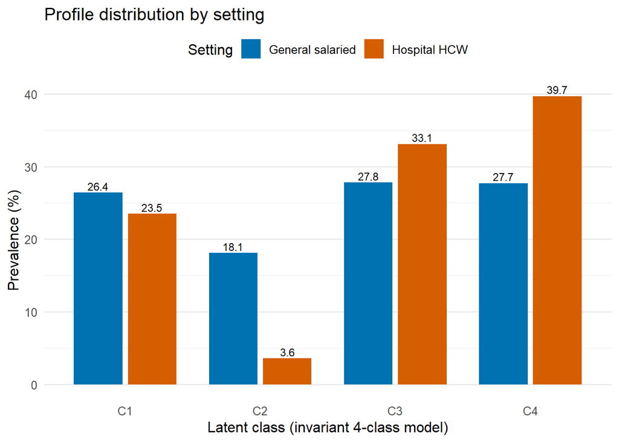

```r
g4_inv <- fit_mg(4, measure.inv = TRUE)
gl     <- levels(combo$setting)
prev4  <- group_prev(g4_inv, gl)

prev_df <- as.data.frame(round(100 * prev4, 1))
prev_df$Setting <- rownames(prev_df)
prev_df |>
  dplyr::select(Setting, dplyr::everything()) |>
  knitr::kable("markdown",
    caption = "Class prevalences (%) by setting, from the invariant four-class model. Columns C1-C4 are the shared profiles; rows are the two samples. Differences here reflect a different DISTRIBUTION of the same profiles, not different profiles.")

## visual
prev_long <- prev_df |>
  tidyr::pivot_longer(dplyr::starts_with("C"), names_to = "Class", values_to = "Prevalence")
p_prev <- ggplot(prev_long, aes(Class, Prevalence, fill = Setting)) +
  geom_col(position = position_dodge(width = 0.8), width = 0.72) +
  geom_text(aes(label = sprintf("%.1f", Prevalence)),
            position = position_dodge(width = 0.8), vjust = -0.3, size = 3) +
  scale_fill_manual(values = c("General salaried" = "#0072B2", "Hospital HCW" = "#D55E00")) +
  labs(x = "Latent class (invariant 4-class model)", y = "Prevalence (%)",
       title = "Profile distribution by setting") +
  theme_minimal(base_size = 12) +
  theme(legend.position = "top", panel.grid.major.x = element_blank())
p_prev
```

```r
ggsave("Figure_MG_prevalences.png", p_prev, width = 8, height = 5, dpi = 300, bg = "white")
```

Class prevalences (%) by setting, from the invariant four-class model. Columns C1-C4 are the shared profiles; rows are the two samples. Differences here reflect a different DISTRIBUTION of the same profiles, not different profiles.

|  | Setting | C1 | C2 | C3 | C4 |
| --- | --- | --- | --- | --- | --- |
| General salaried | General salaried | 26.4 | 18.1 | 27.8 | 27.7 |
| Hospital HCW | Hospital HCW | 23.5 | 3.6 | 33.1 | 39.7 |

## What are the four shared profiles? (invariant-model item probabilities)

The prevalence table above only becomes interpretable once we know **what C1–C4 are**. Because measurement invariance is imposed (`measure.inv = TRUE`), a *single* set of item-response probabilities (`rho`) describes both settings, so we print them from the **same `g4_inv`** whose prevalences are tabled above and label each class **from its `rho`** (data-driven, not guessed from class size). Each item is scored by the probability of its two high-frequency categories (*fairly often* + *almost always/always*), the metric used throughout this notebook and in Table 3 of the main analysis.

```r
## Shared item-response probabilities of the invariant 4-class model (g4_inv).
## measure.inv = TRUE -> rho is common to both settings, so one profile set fits both.
rho_inv <- get_rho(g4_inv)                       # 13 items; each a K x 4 rho matrix
Kinv    <- ncol(get_post_list(g4_inv)[[1]])      # = 4
t2_inv  <- top2_mat(rho_inv, Kinv)               # top-2 endorsement per item x class

## Family means (mean top-2 by behaviour type) -> the compact, interpretable summary.
fam_inv <- t(vapply(c("Destructive", "Laissez-faire", "Constructive"),
             function(ty) colMeans(t2_inv[item_type == ty, , drop = FALSE]), numeric(Kinv)))

## Simple DATA-DRIVEN label per class from its family scores (no hand-coded numbers):
## strong/plain constructive (high constructive, negligible destructive), toxic/
## ambivalent (elevated destructive OR laissez-faire), else passive/disengaged.
lab_inv <- vapply(seq_len(Kinv), function(k) {
  con <- fam_inv["Constructive", k]; lf <- fam_inv["Laissez-faire", k]; de <- fam_inv["Destructive", k]
  if (con >= 0.80 && de < 0.10)        "Strong constructive"
  else if (con >= 0.55 && de < 0.10)   "Constructive"
  else if (de >= 0.08 || lf >= 0.15)   "Toxic / ambivalent (destructive + avoidant)"
  else                                 "Passive / disengaged (low on all)"
}, character(1))

## (a) per-class family scores + label -> THIS is what C1-C4 in the prevalence table are.
ord_inv <- order(-fam_inv["Constructive", ])     # most -> least constructive
tibble::tibble(
  Class             = paste0("C", 1:Kinv),
  `Constructive %`  = round(fam_inv["Constructive", ] * 100),
  `Laissez-faire %` = round(fam_inv["Laissez-faire", ] * 100),
  `Destructive %`   = round(fam_inv["Destructive", ] * 100),
  Label             = lab_inv)[ord_inv, ] |>
  knitr::kable("markdown",
    caption = "Invariant four-class model: family scores (mean top-2 endorsement by behaviour type, %) and a data-driven label for each SHARED profile. This is what C1-C4 in the prevalence table above represent (ordered most to least constructive).")

## (b) full detail: top-2 endorsement per ITEM x class, grouped by behaviour type.
detail <- data.frame(Item = item_lab, Type = item_type, round(t2_inv * 100),
                     check.names = FALSE, row.names = NULL)
colnames(detail)[-(1:2)] <- paste0("C", 1:Kinv)
detail[order(factor(detail$Type, levels = c("Destructive", "Laissez-faire", "Constructive"))), ] |>
  knitr::kable("markdown",
    caption = "Invariant four-class model: item-response probabilities (rho, as P of the two high-frequency categories, %) for each item x shared profile, grouped by behaviour type. Confirms the class labels above.")
```

Invariant four-class model: family scores (mean top-2 endorsement by behaviour type, %) and a data-driven label for each SHARED profile. This is what C1-C4 in the prevalence table above represent (ordered most to least constructive).

| Class | Constructive % | Laissez-faire % | Destructive % | Label |
| --- | --- | --- | --- | --- |
| C1 | 83 | 12 | 3 | Strong constructive |
| C3 | 73 | 9 | 3 | Constructive |
| C4 | 19 | 18 | 10 | Toxic / ambivalent (destructive + avoidant) |
| C2 | 10 | 6 | 3 | Passive / disengaged (low on all) |

Invariant four-class model: item-response probabilities (rho, as P of the two high-frequency categories, %) for each item x shared profile, grouped by behaviour type. Confirms the class labels above.

|  | Item | Type | C1 | C2 | C3 | C4 |
| --- | --- | --- | --- | --- | --- | --- |
| 1 | Humiliates employees | Destructive | 2 | 2 | 1 | 8 |
| 3 | Gestures of displeasure | Destructive | 7 | 6 | 7 | 19 |
| 7 | Spreads false information | Destructive | 4 | 3 | 3 | 8 |
| 9 | Berates by phone / rude email | Destructive | 1 | 1 | 3 | 6 |
| 4 | Avoids making decisions | Laissez-faire | 9 | 5 | 5 | 21 |
| 6 | Avoids involvement in work | Laissez-faire | 19 | 7 | 18 | 16 |
| 8 | Absent when needed | Laissez-faire | 7 | 6 | 4 | 18 |
| 2 | Encourages creative ideas | Constructive | 61 | 11 | 50 | 14 |
| 5 | Recognizes good performance | Constructive | 80 | 16 | 71 | 21 |
| 10 | Seeks to develop capabilities | Constructive | 82 | 4 | 70 | 13 |
| 11 | Sets clear objectives | Constructive | 83 | 6 | 72 | 18 |
| 12 | Defines / explains tasks | Constructive | 97 | 12 | 92 | 26 |
| 13 | Flexible, open to innovation | Constructive | 96 | 9 | 84 | 19 |

The figure below shows the **full four-category** item-response probabilities of the same shared profiles (Figure-2 grammar of the main analysis), so the shape of each class — not just its top-two summary — is visible.

Figure 1: Invariant four-class model — full item-response probabilities of the SHARED profiles (item probs held equal across settings). Horizontal stacked bars give P(response category) per item; rows = items grouped by behaviour type; columns = the four shared classes ordered most to least constructive with their data-driven labels. These are the profiles whose group-specific prevalences are compared above.

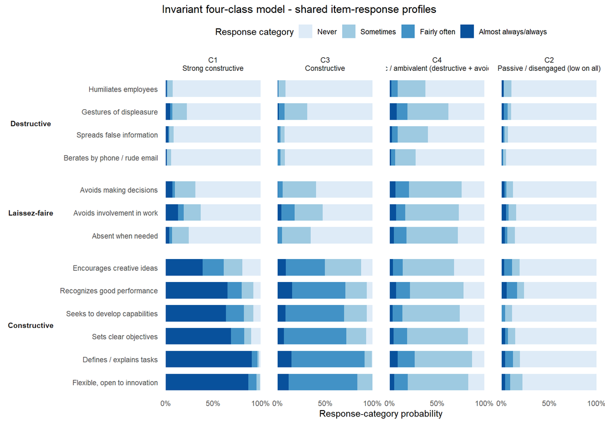

```r
cats <- c("Never", "Sometimes", "Fairly often", "Almost always/always")
blue <- c("#DEEBF7", "#9ECAE1", "#4292C6", "#08519C")
## column labels = C# + data-driven label, ordered most -> least constructive (ord_inv)
lab_cols <- paste0("C", 1:Kinv, "\n", lab_inv)[ord_inv]

rho_long_inv <- purrr::map_dfr(seq_along(common_items), function(j) {
  m <- rho_inv[[j]]                                  # K x 4 (rows = class, cols = category)
  tidyr::expand_grid(class = 1:Kinv, cat = 1:4) |>
    dplyr::mutate(p = as.vector(t(m))[(class - 1) * 4 + cat], item = common_items[j])
}) |>
  dplyr::mutate(
    pos   = match(item, common_items),
    type  = factor(item_type[pos], levels = c("Destructive", "Laissez-faire", "Constructive")),
    label = factor(item_lab[pos],  levels = rev(item_lab)),
    cat   = factor(cats[cat], levels = cats),
    ## levels AND labels both permuted by ord_inv -> column order and printed label stay locked
    class = factor(paste0("C", class), levels = paste0("C", 1:Kinv)[ord_inv], labels = lab_cols))

p_inv <- ggplot(rho_long_inv, aes(p, label, fill = cat)) +
  geom_col(width = .72) +
  facet_grid(type ~ class, scales = "free_y", space = "free_y", switch = "y") +
  scale_fill_manual(values = blue, name = "Response category") +
  scale_x_continuous(labels = scales::percent_format(accuracy = 1),
                     breaks = c(0, .5, 1), expand = expansion(mult = .04)) +
  labs(x = "Response-category probability", y = NULL,
       title = "Invariant four-class model - shared item-response profiles") +
  theme_minimal(base_size = 11) +
  theme(legend.position = "top", panel.spacing.x = unit(.8, "lines"),
        panel.grid = element_blank(), strip.placement = "outside",
        strip.text.y.left = element_text(face = "bold", angle = 0))
p_inv
ggsave("Figure_MG_invariant_profiles.png", p_inv, width = 10, height = 7, dpi = 300, bg = "white")
```

# Separate single-group enumeration: do new classes appear?

Fitting each sample **alone** (k = 2-6) asks whether the *number* of classes the data prefer differs by setting — and, with the profile comparison below, whether qualitatively new profiles emerge in the hospital sample.

```r
fit_single <- function(nclass, data) {
  RNGkind("Mersenne-Twister")
  g <- NULL
  for (s in 2125:2134) {
    g <- tryCatch(glca::glca(item_f, data = data, nclass = nclass,
                             n.init = n_init, seed = s, verbose = FALSE),
                  error = function(e) NULL)
    if (!is.null(g)) break
  }
  g
}

enum_by_group <- function(data, label) {
  n <- nrow(data)
  purrr::map_dfr(2:6, function(k) {
    g <- tryCatch(fit_single(k, data), error = function(e) NULL)
    if (is.null(g)) return(tibble::tibble(Setting = label, k = k,
                                          logLik = NA_real_, AIC = NA_real_,
                                          BIC = NA_real_, entropy = NA_real_))
    ll <- gof_get(g, "loglik"); aic <- gof_get(g, "aic"); bic <- gof_get(g, "bic")
    tibble::tibble(Setting = label, k = k, logLik = round(ll, 1),
                   AIC = round(aic, 1), BIC = round(bic, 1),
                   entropy = round(relative_entropy(get_post_list(g)[[1]]), 3))
  })
}

gen_only  <- combo[combo$setting == "General salaried", ]
hosp_only <- combo[combo$setting == "Hospital HCW", ]
enum_sep <- dplyr::bind_rows(
  enum_by_group(gen_only,  "General salaried"),
  enum_by_group(hosp_only, "Hospital HCW"))
enum_sep |>
  knitr::kable("markdown",
    caption = "Separate single-group enumeration (each sample alone, k = 2-6). Compare the BIC-preferred k across settings; a very different preferred k or shape would indicate the hospital sample needs a different structure.")
```

Separate single-group enumeration (each sample alone, k = 2-6). Compare the BIC-preferred k across settings; a very different preferred k or shape would indicate the hospital sample needs a different structure.

| Setting | k | logLik | AIC | BIC | entropy |
| --- | --- | --- | --- | --- | --- |
| General salaried | 2 | -23500.0 | 47158.0 | 47594.2 | 0.887 |
| General salaried | 3 | -22157.2 | 44552.4 | 45209.4 | 0.896 |
| General salaried | 4 | -21303.7 | 42925.5 | 43803.4 | 0.896 |
| General salaried | 5 | -20902.5 | 42203.0 | 43301.7 | 0.896 |
| General salaried | 6 | -20696.3 | 41870.7 | 43190.3 | 0.884 |
| Hospital HCW | 2 | -12029.5 | 24217.0 | 24602.5 | 0.846 |
| Hospital HCW | 3 | -11565.5 | 23369.0 | 23949.7 | 0.862 |
| Hospital HCW | 4 | -11350.9 | 23019.8 | 23795.6 | 0.859 |
| Hospital HCW | 5 | -11203.1 | 22804.1 | 23775.1 | 0.852 |
| Hospital HCW | 6 | -11103.6 | 22685.2 | 23851.3 | 0.850 |

# Profile comparison at k = 4 (each sample fitted alone)

Side-by-side item-response profiles let you see whether the four profiles *look* the same in both settings. Because latent-class labels are arbitrary (label switching), within each setting the four classes are ordered by their mean constructive endorsement (strongest constructive first), which roughly aligns them for visual comparison; verify the alignment against the numbers.

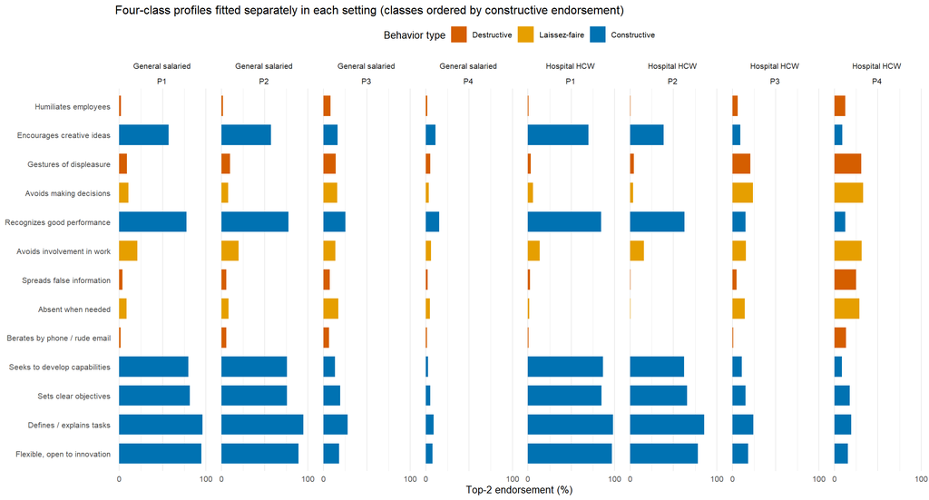

```r
## item_type / item_lab are defined once in the `item-meta` chunk above (reused here).

## order a fitted 4-class model's classes by mean constructive endorsement (desc)
order_by_constructive <- function(g) {
  K <- length(get_post_list(g)[[1]][1, ]); rho <- get_rho(g)
  t2 <- top2_mat(rho, K)
  cs <- colMeans(t2[item_type == "Constructive", , drop = FALSE])
  order(cs, decreasing = TRUE)
}

profile_tbl <- function(g, label) {
  K <- ncol(get_post_list(g)[[1]]); rho <- get_rho(g)
  t2 <- top2_mat(rho, K)[, order_by_constructive(g), drop = FALSE]
  colnames(t2) <- paste0(label, " P", seq_len(K))
  tibble::tibble(item = item_lab, type = item_type) |> dplyr::bind_cols(as.data.frame(round(t2, 2)))
}

g4_gen  <- fit_single(4, gen_only)
g4_hosp <- fit_single(4, hosp_only)

comp <- dplyr::left_join(profile_tbl(g4_gen, "Gen"), profile_tbl(g4_hosp, "Hosp"),
                         by = c("item", "type"))
comp |>
  knitr::kable("markdown",
    caption = "Top-2 endorsement (categories 3+4) per item for the four-class model fitted SEPARATELY in each setting, classes ordered by constructive endorsement (P1 = strongest constructive ... P4 = least). Compare columns Gen P1-P4 vs Hosp P1-P4 to judge whether the profiles match.")

## faceted figure: profile (ordered) x setting. Build long form explicitly so
## column names are unambiguous (no reliance on parse_number / tidyselect guesses).
long_one <- function(g, label) {
  K <- ncol(get_post_list(g)[[1]]); rho <- get_rho(g)
  t2 <- top2_mat(rho, K)[, order_by_constructive(g), drop = FALSE]
  df <- data.frame(item = factor(item_lab, levels = rev(item_lab)),
                   type = factor(item_type, levels = c("Destructive","Laissez-faire","Constructive")))
  for (p in seq_len(K)) df[[paste0("P", p)]] <- t2[, p]
  tidyr::pivot_longer(df, dplyr::starts_with("P"), names_to = "cls", values_to = "p") |>
    dplyr::mutate(setting = label)
}
fig_df <- dplyr::bind_rows(long_one(g4_gen, "General salaried"),
                           long_one(g4_hosp, "Hospital HCW"))
p_profiles <- ggplot(fig_df, aes(p, item, fill = type)) +
  geom_col(width = 0.7) +
  facet_grid(. ~ setting + cls) +
  scale_fill_manual(values = c("Destructive" = "#D55E00", "Laissez-faire" = "#E69F00",
                               "Constructive" = "#0072B2")) +
  scale_x_continuous(breaks = c(0, .5, 1), labels = c("0", "", "100")) +
  labs(x = "Top-2 endorsement (%)", y = NULL, fill = "Behavior type",
       title = "Four-class profiles fitted separately in each setting (classes ordered by constructive endorsement)") +
  theme_minimal(base_size = 10) +
  theme(legend.position = "top", panel.grid.major.y = element_blank(),
        panel.spacing.x = unit(0.6, "lines"), strip.text = element_text(size = 8))
p_profiles
```

```r
ggsave("Figure_MG_profile_comparison.png", p_profiles, width = 13, height = 7, dpi = 300, bg = "white")
```

Top-2 endorsement (categories 3+4) per item for the four-class model fitted SEPARATELY in each setting, classes ordered by constructive endorsement (P1 = strongest constructive … P4 = least). Compare columns Gen P1-P4 vs Hosp P1-P4 to judge whether the profiles match.

| item | type | Gen P1 | Gen P2 | Gen P3 | Gen P4 | Hosp P1 | Hosp P2 | Hosp P3 | Hosp P4 |
| --- | --- | --- | --- | --- | --- | --- | --- | --- | --- |
| Humiliates employees | Destructive | 0.02 | 0.02 | 0.08 | 0.02 | 0.01 | 0.01 | 0.06 | 0.13 |
| Encourages creative ideas | Constructive | 0.57 | 0.57 | 0.16 | 0.11 | 0.70 | 0.38 | 0.09 | 0.09 |
| Gestures of displeasure | Destructive | 0.09 | 0.10 | 0.14 | 0.05 | 0.03 | 0.05 | 0.21 | 0.31 |
| Avoids making decisions | Laissez-faire | 0.11 | 0.08 | 0.16 | 0.04 | 0.06 | 0.04 | 0.24 | 0.33 |
| Recognizes good performance | Constructive | 0.78 | 0.78 | 0.25 | 0.15 | 0.85 | 0.63 | 0.15 | 0.12 |
| Avoids involvement in work | Laissez-faire | 0.21 | 0.20 | 0.14 | 0.06 | 0.14 | 0.16 | 0.16 | 0.31 |
| Spreads false information | Destructive | 0.04 | 0.06 | 0.07 | 0.02 | 0.02 | 0.01 | 0.05 | 0.25 |
| Absent when needed | Laissez-faire | 0.09 | 0.08 | 0.17 | 0.05 | 0.01 | 0.01 | 0.14 | 0.29 |
| Berates by phone / rude email | Destructive | 0.02 | 0.06 | 0.06 | 0.01 | 0.01 | 0.00 | 0.01 | 0.13 |
| Seeks to develop capabilities | Constructive | 0.80 | 0.76 | 0.13 | 0.03 | 0.86 | 0.62 | 0.11 | 0.09 |
| Sets clear objectives | Constructive | 0.82 | 0.76 | 0.19 | 0.05 | 0.85 | 0.66 | 0.15 | 0.18 |
| Defines / explains tasks | Constructive | 0.96 | 0.95 | 0.28 | 0.09 | 0.98 | 0.86 | 0.24 | 0.19 |
| Flexible, open to innovation | Constructive | 0.95 | 0.89 | 0.18 | 0.08 | 0.97 | 0.78 | 0.18 | 0.15 |

# Verdict

```r
## Assemble a compact, data-driven verdict from the objects computed above.
bic_inv4  <- inv_tbl$BIC[inv_tbl$k == 4 & inv_tbl$model == "invariant"]
bic_free4 <- inv_tbl$BIC[inv_tbl$k == 4 & inv_tbl$model == "free"]
p_lrt4    <- inv_tbl$LRT_p[inv_tbl$k == 4 & inv_tbl$model == "free"]
## Lead criterion = BIC / approximate Bayes factor (the Cheng-Rensvold analog),
## robust to the large-n over-rejection of the chi-square LRT. dBIC4 = BIC(free) -
## BIC(invariant); >= 2 positive, >= 6 strong, >= 10 very strong evidence FOR
## invariance. p_lrt4 is retained only for the caveat (p_lrt4_disp below), NOT the rule.
dBIC4     <- bic_free4 - bic_inv4
inv_ok    <- isTRUE(dBIC4 >= 6)
## Display-only format for the LRT p (options(scipen=999) would otherwise print a
## tiny p as a long fixed-notation string). Keeps p_lrt4 numeric for inv_ok above.
p_lrt4_disp <- if (length(p_lrt4) == 1 && !is.na(p_lrt4))
                 (if (p_lrt4 < 0.001) "<0.001" else sprintf("%.3f", p_lrt4)) else "NA"

pick <- function(kvec, bicvec) { i <- which.min(bicvec); if (length(i)) kvec[i] else NA }
bic_pooled_min_k <- pick(enum_pooled$k, enum_pooled$BIC)
gen_best  <- pick(enum_sep$k[enum_sep$Setting == "General salaried"], enum_sep$BIC[enum_sep$Setting == "General salaried"])
hosp_best <- pick(enum_sep$k[enum_sep$Setting == "Hospital HCW"],   enum_sep$BIC[enum_sep$Setting == "Hospital HCW"])

cat(sprintf(paste0(
  "- **Pooled enumeration:** BIC is minimised at k = %s in the two-group data.\n",
  "- **Measurement invariance (k = 4):** lead criterion BIC(invariant) = %s < BIC(free) = %s (ΔBIC = %s favouring the shared-profile model) -> invariance %s. The chi-square LRT (p = %s) rejects, but this reflects the large pooled sample over-powering the deviance test, not substantive non-invariance; AIC/SABIC (lighter penalties) and the LRT lean toward the free model, and at k = 3 BIC itself prefers free.\n",
  "- **Separate enumeration:** BIC-preferred k is %s (general) and %s (hospital).\n",
  "- **Reading:** if invariance holds, the four profiles are shared across settings (robust to place/occupation) and the two samples differ mainly in prevalences (table above). If it is rejected, inspect the profile-comparison table/figure to see which profiles differ and whether the hospital sample needs an extra class.\n"),
  bic_pooled_min_k,
  ifelse(length(bic_inv4), bic_inv4, NA), ifelse(length(bic_free4), bic_free4, NA),
  ifelse(length(dBIC4), round(dBIC4, 1), NA),
  ifelse(inv_ok, "SUPPORTED", "NOT clearly supported"),
  p_lrt4_disp,
  gen_best, hosp_best))
```

- **Pooled enumeration:** BIC is minimised at k = 6 in the two-group data.
- **Measurement invariance (k = 4):** lead criterion BIC(invariant) = 67386.22 < BIC(free) = 67835.56 (ΔBIC = 449.3 favouring the shared-profile model) -> invariance SUPPORTED. The chi-square LRT (p = <0.001) rejects, but this reflects the large pooled sample over-powering the deviance test, not substantive non-invariance; AIC/SABIC (lighter penalties) and the LRT lean toward the free model, and at k = 3 BIC itself prefers free.
- **Separate enumeration:** BIC-preferred k is 6 (general) and 5 (hospital).
- **Reading:** if invariance holds, the four profiles are shared across settings (robust to place/occupation) and the two samples differ mainly in prevalences (table above). If it is rejected, inspect the profile-comparison table/figure to see which profiles differ and whether the hospital sample needs an extra class.